# Statistical inference with the GSS data

## Setup

### Load packages

```r
library(ggplot2)
library(dplyr)
```

### Load data

```r
load("~/Desktop/Coursera Project/data.Rdata")
```

## Part 1: Data

I cannot find any description of the data on the website on within this course. However, I’m going to assume it is a random survey carried out on random individuals in the US every year.

Since it is randomly assigned, we can infer connections but we cannot infer causation.

I’d be worried that those surveyed year-after-year might be the same. If they’re the same, then tests that lump different years of data together would fail the indepedence condition for most hypothesis tests.

For the purposes of this test, I’ll assume they’re not the same individuals every year. * * *

## Part 2: Research question

I’d like to explore the difference in black and white’s perception of how discrimination impacts the life outcomes of blacks in America. I’d like to explore this across various demographics including gender, degree attainment, religion, and political party affiliation. I’d also like to examine how this perception has changed across time.

I’m am going to use the response from black and white’s to the following question as an indicator for how people perceive discrimination impacts life outcomes:

“On average, African-Americans have jobs, income, and housing than white people. Do you think these differences are mainly due to discrimination?”

## Part 3: Exploratory data analysis

Before we can dig into the differences across certain demographics, lets first simple examine how white and black’s responses to this question have changed across time.

```r
q1 <- gss %>% group_by(year, race, racdif1) %>% summarise(counts=n()) %>% filter(is.na(racdif1) != TRUE, race != 'Other')
```

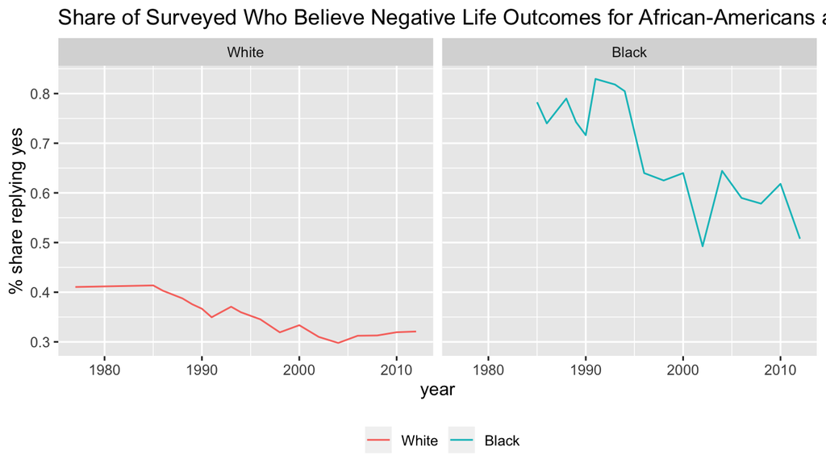

```r
q1 <- q1 %>% group_by(year,race) %>% mutate(share = counts/sum(counts, is.na=TRUE))
q1 <- subset(q1, racdif1 == 'Yes')
ggplot(data=q1, aes(x=year, y=share, fill=race, colour=race)) + geom_line() + facet_wrap(~race) + ggtitle('Share of Surveyed Who Believe Negative Life Outcomes for African-Americans are due to Discrimination') + ylab('% share replying yes') + theme(legend.position="bottom", legend.title = element_blank())
```

It seems answers to this question have shifted across time with 1994 being the time in which this decreased. Although we saw a decline across both races, the decline seems to be more substantial for African-Americans. It is not clear if this is a significant change. We will test this later.

For now, lets look at some shifts within demographics across time for African-Americans and Whites. Let us generate views for the following demographics, one-by-one, comparing responses prior to 1996 and after 1996:

1. Gender
2. Highest Degree of Attainment
3. Political Party Affiliation
4. Religion

```r
gss <- gss %>% mutate(sample = case_when(year >= 1996 ~ '>= 1996', year < 1996 ~ '< 1996'))

q1 <- gss %>% group_by(sample, race, sex, racdif1) %>% summarise(counts=n()) %>% filter(is.na(racdif1) != TRUE, race != 'Other', is.na(sex) != TRUE)
```

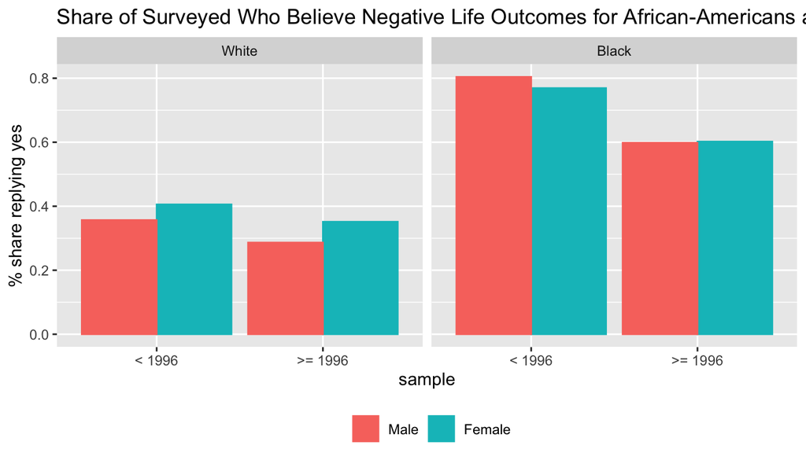

```r
q1 <- q1 %>% group_by(sample,race,sex) %>% mutate(share = counts/sum(counts, is.na=TRUE))
q1 <- subset(q1, racdif1 == 'Yes')
ggplot(data=q1, aes(x=sample, y=share, fill=sex, colour=sex)) + geom_bar(stat='identity', position='dodge') + facet_wrap(~race) + ggtitle('Share of Surveyed Who Believe Negative Life Outcomes for African-Americans are due to Discrimination') + ylab('% share replying yes') + theme(legend.position="bottom", legend.title = element_blank())
```

```r
q1 <- gss %>% group_by(sample, race, degree, racdif1) %>% summarise(counts=n()) %>% filter(is.na(racdif1) != TRUE, race != 'Other', is.na(degree) != TRUE)
```

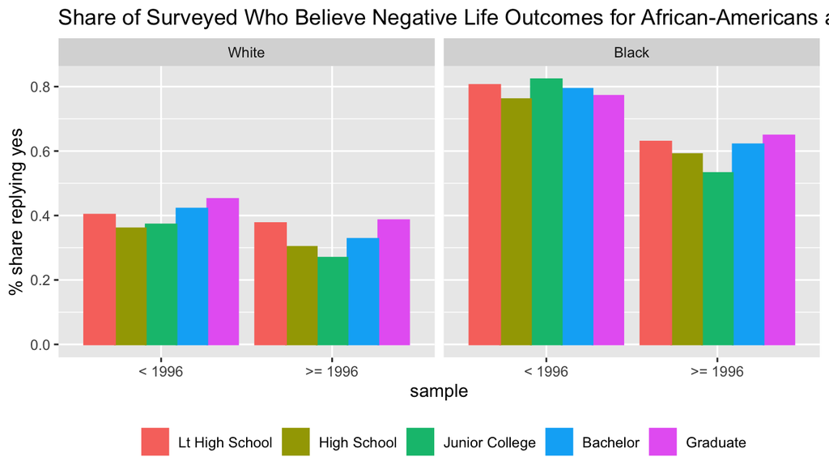

```r
q1 <- q1 %>% group_by(sample,race,degree) %>% mutate(share = counts/sum(counts, is.na=TRUE))
q1 <- subset(q1, racdif1 == 'Yes')
ggplot(data=q1, aes(x=sample, y=share, fill=degree, colour=degree)) + geom_bar(stat='identity', position='dodge') + facet_wrap(~race) + ggtitle('Share of Surveyed Who Believe Negative Life Outcomes for African-Americans are due to Discrimination') + ylab('% share replying yes') + theme(legend.position="bottom", legend.title = element_blank())
```

```r
q1 <- gss %>% group_by(sample, race, partyid, racdif1) %>% summarise(counts=n()) %>% filter(is.na(racdif1) != TRUE, race != 'Other', is.na(partyid) != TRUE)
```

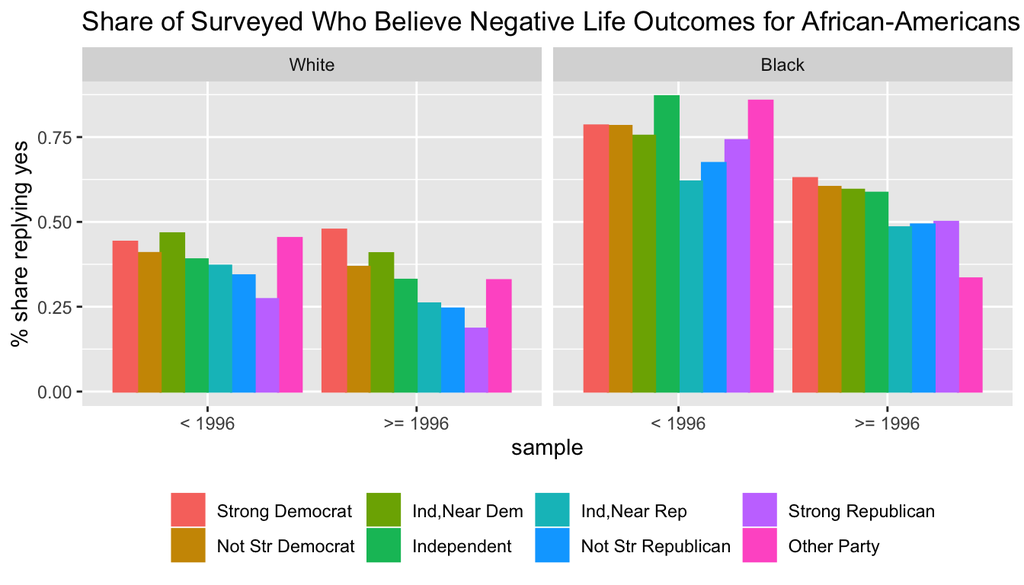

```r
q1 <- q1 %>% group_by(sample,race,partyid) %>% mutate(share = counts/sum(counts, is.na=TRUE))
q1 <- subset(q1, racdif1 == 'Yes')
ggplot(data=q1, aes(x=sample, y=share, fill=partyid, colour=partyid)) + geom_bar(stat='identity', position='dodge') + facet_wrap(~race) + ggtitle('Share of Surveyed Who Believe Negative Life Outcomes for African-Americans are due to Discrimination') + ylab('% share replying yes') + theme(legend.position="bottom", legend.title = element_blank())
```

```r
q1 <- gss %>% group_by(sample, race, relig, racdif1) %>% summarise(counts=n()) %>% filter(is.na(racdif1) != TRUE, race != 'Other', is.na(relig) != TRUE)
```

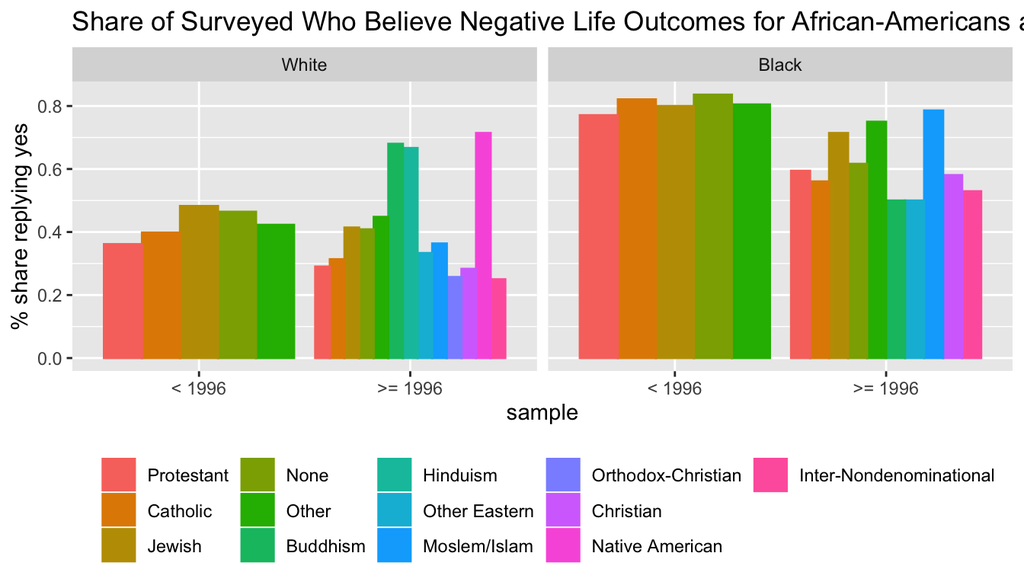

```r
q1 <- q1 %>% group_by(sample,race,relig) %>% mutate(share = counts/sum(counts, is.na=TRUE))
q1 <- subset(q1, racdif1 == 'Yes')
ggplot(data=q1, aes(x=sample, y=share, fill=relig, colour=relig)) + geom_bar(stat='identity', position='dodge') + facet_wrap(~race) + ggtitle('Share of Surveyed Who Believe Negative Life Outcomes for African-Americans are due to Discrimination') + ylab('% share replying yes') + theme(legend.position="bottom", legend.title = element_blank())
```

From the above, it seems pretty clear that just about any demographic we are interested in within each race saw a decline after 1996 in those responding ‘yes’.

I now want to answer a few questions:

1. is the decline after 1996 significant for both races?
2. is the difference between races significant?
3. if different in aggregate, is this share dependent on political affiliation for white individuals?

## Part 4: Inference

Lets begin by calculate the confidence interval for the difference in the share replying ‘yes’ for each race before and after 1996.

First, we must check if we meet all of the conditions required for calculating the CIs for two proportions.

1. success-failure conditions
2. indepedence

```r
q1 <- gss %>% group_by(race, sample,racdif1) %>% summarise(counts=n()) %>% filter(is.na(racdif1) != TRUE, race != 'Other')
q1 <- q1 %>% group_by(race,sample) %>% mutate(group_total = sum(counts))
q1 <- q1 %>% group_by(race,sample) %>% mutate(share = counts/group_total)

q1
```

```
## # A tibble: 8 x 6
## # Groups:   race, sample [4]
##   race  sample  racdif1 counts group_total share
##   <fct> <chr>   <fct>    <int>       <int> <dbl>
## 1 White < 1996  Yes       3715        9678 0.384
## 2 White < 1996  No        5963        9678 0.616
## 3 White >= 1996 Yes       3203        9952 0.322
## 4 White >= 1996 No        6749        9952 0.678
## 5 Black < 1996  Yes        910        1161 0.784
## 6 Black < 1996  No         251        1161 0.216
## 7 Black >= 1996 Yes       1137        1891 0.601
## 8 Black >= 1996 No         754        1891 0.399
```

We can see from the above that our count columns imply than we have more than 10 for both the yes and no condition by race. This means the success-failure condition is satisfied.

For independence, I think it is safe to assume that white and black individuals are independent of each-other. I think it is also safe to assume that every year’s survey result is independent from the other.

Thus, we can carry forward with our CI.

```r
q1 <- subset(q1, racdif1 == 'Yes')
q1_a <- q1 %>% select(p1 = share, n1 = group_total, sample, race)
q1_a <- q1_a %>% filter(sample == '>= 1996', is.na(sample) != 'TRUE')
q1_b <- q1 %>% select(p2 = share, n2 = group_total, sample, race)
q1_b <- q1_b %>% filter(sample == '< 1996', is.na(sample) != 'TRUE')

q1 <- inner_join(q1_a,q1_b,by="race")
q1 <- q1 %>% mutate(se1 = (p1*(1-p1))/n1, se2 = (p2*(1-p2))/n2)
q1 <- q1 %>% mutate(se = sqrt(se1+se2))
q1 <- q1 %>% mutate(diff_upper = (p1-p2)+1.96*se)
q1 <- q1 %>% mutate(diff_lower = (p1-p2)-1.96*se)
q1 <- q1 %>% select(race,sample.x,p1,n1,p2,n2,se,diff_upper,diff_lower)
q1 <- subset(q1, n1 >= 10 & n2 >= 10)
q1 <- q1 %>% mutate(point_estimate = p1-p2)
table <- q1 %>% select(race, point_estimate, diff_lower, diff_upper)
table
```

```
## # A tibble: 2 x 5
## # Groups:   sample.x, race [2]
##   sample.x race  point_estimate diff_lower diff_upper
##   <chr>    <fct>          <dbl>      <dbl>      <dbl>
## 1 >= 1996  White        -0.0620    -0.0754    -0.0487
## 2 >= 1996  Black        -0.183     -0.215     -0.150
```

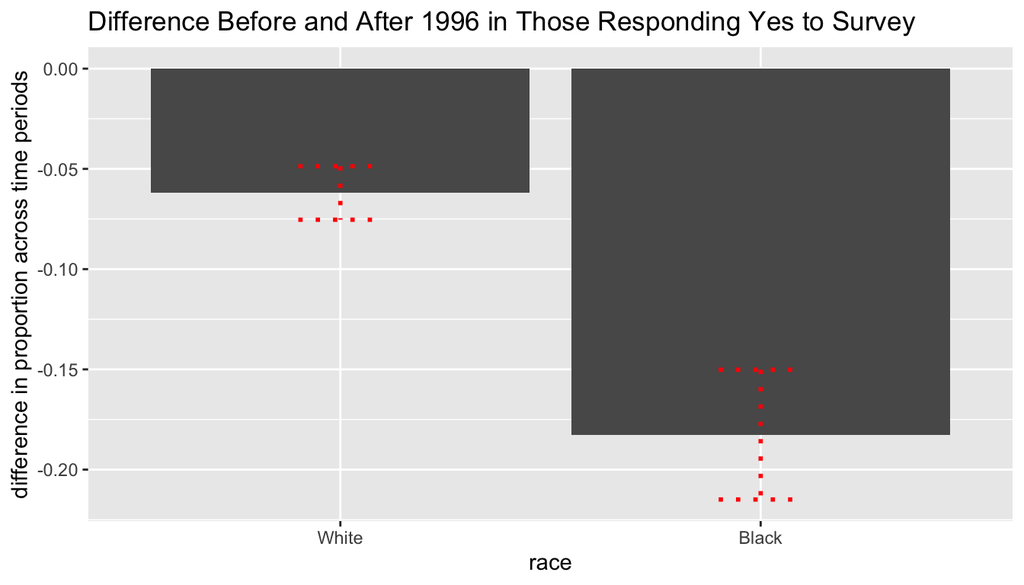

```r
ggplot(data=q1, aes(x=race, y=point_estimate)) + geom_bar(stat='identity') + geom_errorbar(aes(ymin = diff_lower, ymax = diff_upper),width = 0.2,linetype = "dotted",position = position_dodge(width = 0.5), color="red", size=1) + ggtitle('Difference Before and After 1996 in Those Responding Yes to Survey') + ylab('difference in proportion across time periods') + theme(legend.position="bottom", legend.title = element_blank())
```

It is clear that our confidence intervals imply that we might have a significant difference here. But let us perform a hypothesis test to do this.

First, we must make sure we fulfill the requirements for a hypothesis test. Although the indepdence condition is the same for both CIs and Hypothesis tests, we must slightly change our test for the success-failure condition. We must calculate the pooled proportion and ensure that the pooled proportion times the sample size for each group is greater than 10.

```r
q1 <- q1 %>% mutate(pooled_proportion = (p1*n1+p2*n2)/(n1+n2))
q1 <- q1 %>% mutate(test_n1 = pooled_proportion*n1, test_n2 = pooled_proportion*n2)
table <- q1 %>% select(race, test_n1, test_n2)
table
```

```
## # A tibble: 2 x 4
## # Groups:   sample.x, race [2]
##   sample.x race  test_n1 test_n2
##   <chr>    <fct>   <dbl>   <dbl>
## 1 >= 1996  White   3507.   3411.
## 2 >= 1996  Black   1268.    779.
```

Perfect. Our tests all have a value greater than 10. This means we can carry on with our hypothesis test.

Let us state our null and alternative hypotheses.

H0: There is not a significant difference in the proportion of both blacks and whites replying yes to the discrimination question before and after 1996. (P After 1996 = P Before 1996) HA: The proportion of both blacks and whites replying ‘yes’ to the discrimination question after 1996 is less than prior to 1996. (P After 1996 < P Before 1996)

```r
q1 <- q1 %>% mutate(pooled_se = sqrt((pooled_proportion*(1-pooled_proportion)/n1)+(pooled_proportion*(1-pooled_proportion)/n2)))
q1 <- q1 %>% mutate(pooled_proportion = (p1*n1+p2*n2)/(n1+n2))
q1 <- q1 %>% mutate(pooled_se = sqrt((pooled_proportion*(1-pooled_proportion)/n1)+(pooled_proportion*(1-pooled_proportion)/n2)))

q1 <- q1 %>% mutate(z_stat = (point_estimate-0)/pooled_se)
q1 <- q1 %>% mutate(p_value_one_sided = round(pnorm(abs(z_stat), lower.tail = FALSE), digits=3))

q1$z_stat
```

```
## [1]  -9.093075 -10.417541
```

```r
q1$p_value_one_sided
```

```
## [1] 0 0
```

Our p-value for both races is near 0. Thus, we reject the null hypothesis and conclude that, for both blacks and whites, the difference in the proportion of both blacks and whites replying ‘yes’ to the discrimination question before and after 1996 is significantly different.

Now that we know this, lets focus on the period closest to us for answering the question “Do a greater proportion of blacks think that poor life outcomes are driven by discrimination compared to whites?”

We will look at the proportion across races for all responses after 1995.

Since we’ve already established the conditions for constructing a CI interval above, lets go ahead and just calculate the CI, infer if we think the hypothesis test will show a difference, and then run the hypothesis test.

```r
gss1996 <- subset(gss, year >= 1996)

q1 <- gss1996 %>% group_by(race,racdif1) %>% summarise(counts=n()) %>% filter(is.na(racdif1) != TRUE, race != 'Other')
q1 <- q1 %>% group_by(race) %>% mutate(group_sum = sum(counts))
q1 <- q1 %>% group_by(race) %>% mutate(share = counts/group_sum)
q1 <- q1 %>% mutate(sample = 'black vs white') %>% filter(racdif1 == 'Yes')

q1_a <- q1 %>% select(p1 = share, n1 = group_sum, sample, race) %>% filter(race == 'White', is.na(sample) != 'TRUE')
q1_b <- q1 %>% select(p2 = share, n2 = group_sum, sample, race) %>% filter(race == 'Black', is.na(sample) != 'TRUE')

q1 <- inner_join(q1_a,q1_b,by="sample")
q1 <- q1 %>% mutate(se1 = (p1*(1-p1))/n1, se2 = (p2*(1-p2))/n2)
q1 <- q1 %>% mutate(se = sqrt(se1+se2))
q1 <- q1 %>% mutate(diff_upper = (p1-p2)+1.96*se)
q1 <- q1 %>% mutate(diff_lower = (p1-p2)-1.96*se)
q1 <- q1 %>% select(sample,p1,n1,p2,n2,se,diff_upper,diff_lower)
q1 <- subset(q1, n1 >= 10 & n2 >= 10)
q1 <- q1 %>% mutate(point_estimate = p1-p2)

table <- q1 %>% select(sample, point_estimate,diff_lower, diff_upper)
table
```

```
## # A tibble: 1 x 5
## # Groups:   race.x [1]
##   race.x sample         point_estimate diff_lower diff_upper
##   <fct>  <chr>                   <dbl>      <dbl>      <dbl>
## 1 White  black vs white         -0.279     -0.303     -0.256
```

It seems pretty clear that the difference in proportions for blacks and whites is substantial and potentially significant. Lets run the test to confirm.

```r
q1 <- q1 %>% mutate(pooled_proportion = (p1*n1+p2*n2)/(n1+n2))
q1 <- q1 %>% mutate(test_n1 = pooled_proportion*n1, test_n2 = pooled_proportion*n2)
table <- q1 %>% select(sample, test_n1, test_n2)
table
```

```
## # A tibble: 1 x 4
## # Groups:   race.x [1]
##   race.x sample         test_n1 test_n2
##   <fct>  <chr>            <dbl>   <dbl>
## 1 White  black vs white   3647.    693.
```

Above, we can see that both proportions have n >= 10. We can also deduce that all of our data points are independent, as they are from different survey years.

Let us state our null and alternative hypotheses.

H0: There is not a significant difference in the proportion of blacks and whites replying yes to the discrimination question. (P black = P white) HA: There IS a significant difference in the proportion of blacks and whites replying yes to the discrimination question. (P black != < P white)

```r
q1 <- q1 %>% mutate(pooled_se = sqrt((pooled_proportion*(1-pooled_proportion)/n1)+(pooled_proportion*(1-pooled_proportion)/n2)))

q1 <- q1 %>% mutate(z_stat = (point_estimate-0)/pooled_se)
q1 <- q1 %>% mutate(p_value_one_sided = 2*pnorm(-abs(z_stat)))

q1$z_stat
```

```
## [1] -23.11712
```

```r
q1$p_value_one_sided
```

```
## [1] 3.115119e-118
```

From the above, we find a test-statistic of -23 and a p-score of nearly zero. There is strong evidence that there exists a significant difference in the proportion of blacks attributing poor life outcomes to discrimination relative to whites.

This is very interesting. But lets do one quick test to see if there are any demographics within the white race that have views independent of what is expected.

Let us examine political affiliation using a chi-square independence test. Let us being by stating our hypothesis.

H0: Political affiliation and the share of those attributing poor life outcomes for blacks to discrimination are independent. H1: Political affiliation and the share of those attributing poor life outcomes for blacks to discrimination are dependent.

Let us now run through our conditions for running a chi-square independence test.

1. independence
1. random sample/assignment: yes, as discussed earlier, this survey is a random sample.
2. sample size: each particular case must have at least five cells: also yes, as we have 8 political affiliations per yes/no response.

And with that, we can run our test!

```r
q1 <- gss1996 %>% group_by(race, partyid,racdif1) %>% summarise(counts=n()) %>% filter(is.na(racdif1) != TRUE, race == 'White', is.na(partyid) != TRUE)
q1 <- q1 %>% group_by(race) %>% mutate(whites_total = sum(counts))
q1 <- q1 %>% group_by(racdif1) %>% mutate(response_total = sum(counts))
q1 <- q1 %>% group_by(partyid) %>% mutate(party_total = sum(counts))
q1 <- q1 %>% mutate(response_share = response_total/whites_total)
q1 <- q1 %>% mutate(party_share = counts/party_total)
q1 <- q1 %>% mutate(expected_total = response_share*party_total)
q1 <- q1 %>% select(race, partyid,racdif1,actual_total=counts, expected_total)

q1 <- q1 %>% mutate(squared_diff = ((actual_total-expected_total)^2)/expected_total)
q1 <- q1 %>% group_by() %>% mutate(chi_square = sum(squared_diff), degrees_of_freedom = 7)
q1 <- q1 %>% mutate(test_statistic = round(pchisq(chi_square,degrees_of_freedom,lower.tail=FALSE), digits=3))
q1$chi_square
```

```
##  [1] 360.4137 360.4137 360.4137 360.4137 360.4137 360.4137 360.4137
##  [8] 360.4137 360.4137 360.4137 360.4137 360.4137 360.4137 360.4137
## [15] 360.4137 360.4137
```

```r
q1$test_statistic
```

```
##  [1] 0 0 0 0 0 0 0 0 0 0 0 0 0 0 0 0
```

From the above, it is clear that we reject the hull hypothesis. Political affiliation and the share of white people attributing poor life outcomes for blacks to discrimination are dependent.

So, in summary, we have learned three things today: a. The share of individuals who believe discrimination impacts the life outcomes of blacks has shifted across time with a significant decline occurring after 1996 for both black and whites. b. Since 1996, the share of individuals who believe discrimination impacts the life outcomes of blacks is significantly different for whites and blacks, with blacks more likely to believe that discrimination is the main driver of poor life outcomes for blacks. c. Although this significant difference exists, within the white population, political party and this share of people are dependent. This means that there are groups of political affiliations that differ unexpectedly from the general population.